# Approaching the Hot Hand with a Cool Head

# Prechecks for file system setup

# The Dataset

The following piece of script needs the precalculated datasets placed in the same directory.The dataset is downloadable from the file sharing service detailed in the README.md file or recreated following the steps there.

Important quantities created (for this article that is): * time_bet - unixtime of the bet transaction (timestamp of the block) * bet_value - transformed from bet ammount in satoshi to bitcoin (1 satoshi = 1e-8 BTC) * streak - length of streak (win/loss) 0 signs that the outcome is different from the previous game’s * label - identifier of the sample, bascially the observed period, check the bitcoin_pricehistory_lowvar.R script or the article for the dates * pwin - implied probability of winning (0-100), set from the scraped data, defined using the address the bet has been sent to * status_pred - status of the next game played * pwin_pred - pwin of the following game * game_changed - logical variable, TRUE if a different game (pwin/odds/mulitplier) have been bet on after the current game

# Summary statistics and Observed distribution of risk choices

The two tables calculated below are featured in Table 1 and 2. Straightforward summary statistics.

```r
pooled_table_unscaled %>%
  group_by(label) %>%
  summarize(
    start_date = as.Date(as.POSIXct(min(time_bet), origin="1970-01-01")),
    n_games = n(),
    n_users = n_distinct(userID),
    tot_bet = sum(bet_value),
    med_bet = median(bet_value),
    .groups = "drop")
```

| label | start_date | n_games | n_users | tot_bet | med_bet |
| --- | --- | --- | --- | --- | --- |
| A | 2012-05-02 | 119399 | 1002 | 46649.21 | 0.03960100 |
| B | 2012-09-17 | 129265 | 2114 | 85280.58 | 0.06000000 |
| C | 2012-12-17 | 252301 | 3405 | 407140.48 | 0.03500000 |
| D | 2013-05-04 | 329155 | 3432 | 100430.21 | 0.02043000 |
| E | 2013-09-11 | 86520 | 1400 | 62920.60 | 0.02958579 |

```r
#bitcoin prices can be added from the bitcoin_pricehistory_lowvar.R script


pooled_table_unscaled %>%
  group_by(label, pwin) %>%
  summarize(n = n(), .groups = "drop") %>%
  pivot_wider(names_from = label, values_from = n) %>%
  mutate(A = A/sum(A, na.rm = TRUE)*100 %>% round(digits = 1)) %>%
  mutate(B = B/sum(B, na.rm = TRUE)*100 %>% round(digits = 1)) %>%
  mutate(C = C/sum(C, na.rm = TRUE)*100 %>% round(digits = 1)) %>%
  mutate(D = D/sum(D, na.rm = TRUE)*100 %>% round(digits = 1)) %>%
  mutate(E = E/sum(E, na.rm = TRUE)*100 %>% round(digits = 1)) %>%
  arrange(pwin)
```

| pwin | A | B | C | D | E |
| --- | --- | --- | --- | --- | --- |
| 0.0015 | 0.38945050 | 2.21869802 | 2.1842957 | 2.6902219 | 5.2253814 |
| 0.0031 | 0.08375280 | 0.07503965 | 0.0404279 | 0.1883611 | 0.1699029 |
| 0.0061 | 0.51926733 | 0.07194523 | 0.1022588 | 0.2324133 | 0.1421637 |
| 0.0122 | 0.10469099 | 0.10830465 | 0.1272290 | 0.1564612 | 0.1167360 |
| 0.0244 | 0.06867729 | 0.11604069 | 0.1779620 | 0.1494737 | 0.1699029 |
| 0.0488 | 0.06197707 | 0.28778092 | 0.1930234 | 0.2032477 | 0.3270920 |
| 0.0977 | 0.26382131 | 0.17328743 | 0.1874745 | 0.1980830 | 0.3085992 |
| 0.1953 | 0.39280061 | 0.22202452 | 0.1922307 | 0.2217800 | 0.2149792 |
| 0.3906 | 0.21608221 | 0.43476579 | 0.1938161 | 0.1756012 | 0.2450301 |
| 0.7813 | 0.39112555 | 0.80686961 | 0.8545349 | 0.3745956 | 0.3629219 |

[output cut: 17 more lines]

# Population-wide observed winning probabilities after winning streaks of different lengths

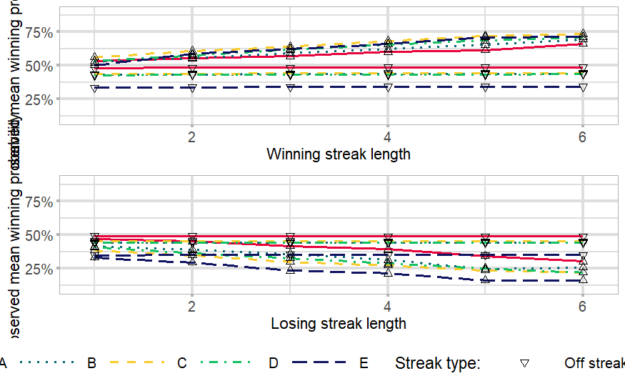

```r
winstreak_obs_winprob <- lapply(seq(1,10), function(i){
  pooled_table_unscaled %>%
  mutate(winstreak = ((status == "win")&(streak == i))) %>%
  group_by(winstreak, label) %>%
  summarize(nof = n(), obs_pwin = sum(status_pred == "win")/n(), .groups = "drop") %>%
  mutate(streak = i) %>%
  group_by(label) %>%
  mutate(n_normed = nof/sum(nof))}) %>%
  bind_rows() %>%
  mutate(winstreak = ifelse(winstreak, "On streak", "Off streak"))

in_win_plot <- ggplot(winstreak_obs_winprob, aes(x=streak, y=obs_pwin, group=interaction(winstreak, label))) +
  geom_line(aes(color = label, linetype = label), size = 1)+
  geom_point(aes(shape = winstreak), size = 2.2) +
    theme_light() +
    theme(
      axis.title.x = element_text(colour="black", size = 13),
      axis.title.y = element_text(colour="black", size = 13),
      axis.text.y = element_text(size = 12),
      axis.text.x = element_text(size = 12),
      legend.position =  "bottom",
      legend.direction = "horizontal",
      legend.text = element_text(colour="black", size = 12),
      legend.title = element_text(colour="black", size = 14),
      line = element_line(size = 2.5, lineend = "butt"),
      legend.key.size = grid::unit(2, "lines"),
      legend.key.width = unit(2,"cm")
    )  +
    scale_color_manual(values = c("#E7033C","#096773","#F9CC2C","#13C062","#111460")) +
    scale_linetype_manual(values = c(1,3,2,4,5)) +
    scale_shape_manual(values=c(25, 24))+
    scale_y_continuous(labels=scales::percent_format(), limits = c(.1,.9)) +
    labs(
      x = "Winning streak length",
      y = "Observed mean winning probability",
      color = "Sample:",
      linetype = "Sample:",
      shape = "Streak type:") +
  guides(colour = guide_legend(order = 1),
          shape = guide_legend(order = 2),
          linetype = guide_legend(order = 1)) +
  xlim(c(0.9,6.1))

lossstreak_obs_winprob <- lapply(seq(1,10), function(i){
  pooled_table_unscaled %>%
  mutate(lossstreak = ((status == "loss")&(streak == i))) %>%
  group_by(lossstreak, label) %>%
  summarize(n = n(), obs_pwin = sum(status_pred == "win")/n(), .groups = "drop") %>%
  mutate(streak = i)
}) %>%
  bind_rows() %>%
  mutate(lossstreak = ifelse(lossstreak, "On streak", "Off streak"))

in_loss_plot <- ggplot(lossstreak_obs_winprob, aes(x=streak, y=obs_pwin, group=interaction(lossstreak, label))) +
  geom_line(aes(color = label, linetype = label), size = 1)+
  geom_point(aes(shape = lossstreak), size = 2.2) +
    theme_light() +
    theme(
      axis.title.x = element_text(colour="black", size = 13),
      axis.title.y = element_text(colour="black", size = 13),
      axis.text.y = element_text(size = 12),
      axis.text.x = element_text(size = 12),
      legend.position =  "bottom",
      legend.direction = "horizontal",
      legend.text = element_text(colour="black", size = 12),
      legend.title = element_text(colour="black", size = 14),
      line = element_line(size = 2.5, lineend = "butt"),
      legend.key.size = grid::unit(2, "lines"),
      legend.key.width = unit(2,"cm")
    )  +
    scale_color_manual(values = c("#E7033C","#096773","#F9CC2C","#13C062","#111460")) +
    scale_linetype_manual(values = c(1,3,2,4,5)) +
    scale_shape_manual(values=c(25, 24))+
    scale_y_continuous(labels=scales::percent_format(), limits = c(.1,.9)) +
    labs(
      x = "Losing streak length",
      y = "Observed mean winning probability",
      color = "Sample:",
      linetype = "Sample:",
      shape = "Streak type:") +
  xlim(c(0.9,6.1))

ggpubr::ggarrange(in_win_plot, in_loss_plot,
                  ncol = 1, nrow = 2,  common.legend = TRUE, legend="bottom")

setwd(WORKDIR)
#ggsave("plots/figure_2_2.2.pdf", device = "pdf", width = 36.52,  height = 12.63,  units = "cm")
ggsave("plots/figure_2_2.2.pdf", device = "pdf", width = 29,  height = 35,  units = "cm")
```

# Mean chosen winning probability after winning and losing streaks of length n.

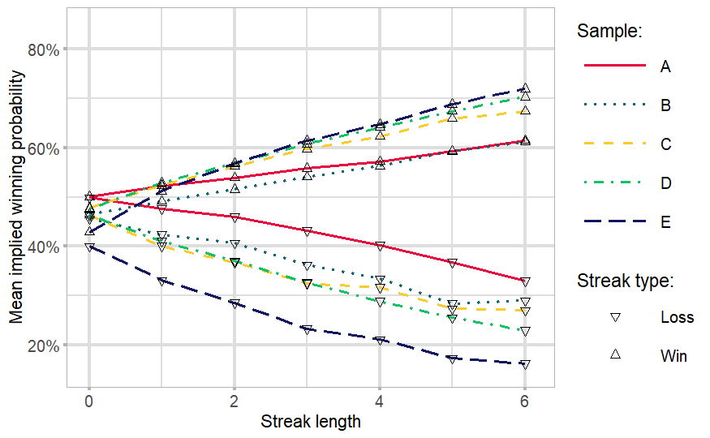

```r
streak_odds_pwin <- pooled_table_unscaled %>%
  group_by(status, streak, label) %>%
  summarize(n = n(),
            mean_pwin = mean(pwin_pred),  median_pwin = median(pwin_pred),
            .groups = "drop") %>% filter(streak < 7) %>%
  mutate(status = ifelse(status == "win","Win","Loss"))

ggplot(streak_odds_pwin, aes(x=streak, y=mean_pwin/100, group=interaction(status, label))) +
  geom_line(aes(color = label, linetype = label), size = 1)+
  geom_point(aes(shape = status), size = 2.2) +
    theme_light() +
    theme(
      axis.title.x = element_text(colour="black", size = 13),
      axis.title.y = element_text(colour="black", size = 13),
      axis.text.y = element_text(size = 12),
      axis.text.x = element_text(size = 12),
      legend.position =  "right",
      legend.direction = "vertical",
      legend.text = element_text(colour="black", size = 12),
      legend.title = element_text(colour="black", size = 14),
      line = element_line(size = 2.5, lineend = "butt"),
      legend.key.size = grid::unit(2, "lines"),
      legend.key.width = unit(2,"cm")
    )  +
    scale_color_manual(values = c("#E7033C","#096773","#F9CC2C","#13C062","#111460")) +
    scale_linetype_manual(values = c(1,3,2,4,5)) +
    scale_shape_manual(values=c(25, 24))+
    scale_y_continuous(labels=scales::percent_format(), limits = c(.15,.85)) +
    labs(
      x = "Streak length",
      y = "Mean implied winning probability",
      color = "Sample:",
      linetype = "Sample:",
      shape = "Streak type:") +
  guides(colour = guide_legend(order = 1),
          shape = guide_legend(order = 2),
          linetype = guide_legend(order = 1)) +
  xlim(c(0,6.1))

setwd(WORKDIR)
ggsave("plots/figure_3_2.1.pdf", device = "pdf", width = 18.26,  height = 12.63,  units = "cm")
```

# Population-wide probabilities of increasing, decreasing, or holding the chosen winning probability after winning and losing streaks.

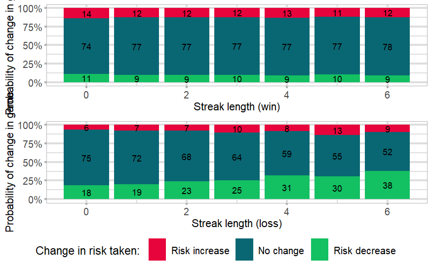

```r
pwin_change_prob <- pooled_table_unscaled %>%
  filter(streak <7) %>%
  mutate(status = ifelse(status == "loss", "Loss", "Win")) %>%
  group_by(streak, status) %>%
  summarize(no_change_prob = sum(!game_changed)/n(),
            change_risk_increased = sum(risk_increased)/n(),
            change_risk_decreased = sum(game_changed&(!risk_increased))/n(),
            .groups = "drop"
            ) %>%
  pivot_longer(cols = c("no_change_prob","change_risk_increased","change_risk_decreased"),
               names_to = "delta")%>%
  mutate(delta = ifelse(delta == "no_change_prob", "No change", ifelse(delta == "change_risk_increased", "Risk increase", "Risk decrease"))) %>%
  mutate(delta = factor(delta, levels = c("Risk increase", "No change", "Risk decrease")))


changeprob_win_plot <-  ggplot(pwin_change_prob %>% filter(status == "Win"),
                               aes(fill=delta, y=value, x=streak)) +
  geom_col(position = "fill") +
  theme_light() +
  geom_text(aes(label = floor(value*100)),position = position_stack(vjust = 0.5)) +
  scale_fill_manual(values = c("#E7033C","#096773","#13C062","#F9CC2C","#111460")) +
  theme(
    axis.title.x = element_text(colour="black", size = 13),
    axis.title.y = element_text(colour="black", size = 13),
    axis.text.y = element_text(size = 12),
    axis.text.x = element_text(size = 12),
    legend.position =  "right",
    legend.direction = "horizontal",
    legend.spacing.x = unit(.8, 'cm'),
    legend.text = element_text(colour="black", size = 12),
    legend.title = element_text(colour="black", size = 14),
    line = element_line(size = 2.5, lineend = "butt"),
    legend.key.size = grid::unit(4, "lines"),
    legend.key.width = unit(.8,"cm"),
    legend.key.height = unit(1,"cm"),
    strip.text.y = element_text(
        size = 13, color = "white", face = "bold"
        )
  )+
  scale_y_continuous(labels=scales::percent_format(accuracy = 5L)) +
  labs(
    x = "Streak length (win)",
    y = "Probability of change in game",
    fill = "Change in risk taken:")

changeprob_loss_plot <-  ggplot(pwin_change_prob %>% filter(status == "Loss"),
                               aes(fill=delta, y=value, x=streak)) +
  geom_col(position = "fill") +
  theme_light() +
  geom_text(aes(label = floor(value*100)),position = position_stack(vjust = 0.5)) +
  scale_fill_manual(values = c("#E7033C","#096773","#13C062","#F9CC2C","#111460")) +
  theme(
    axis.title.x = element_text(colour="black", size = 13),
    axis.title.y = element_text(colour="black", size = 13),
    axis.text.y = element_text(size = 12),
    axis.text.x = element_text(size = 12),
    legend.position =  "right",
    legend.direction = "horizontal",
    legend.spacing.x = unit(.8, 'cm'),
    legend.text = element_text(colour="black", size = 12),
    legend.title = element_text(colour="black", size = 14),
    line = element_line(size = 2.5, lineend = "butt"),
    legend.key.size = grid::unit(4, "lines"),
    legend.key.width = unit(.8,"cm"),
    legend.key.height = unit(1,"cm"),
    strip.text.y = element_text(
        size = 13, color = "white", face = "bold"
        )
  )+
  scale_y_continuous(labels=scales::percent_format(accuracy = 5L)) +
  labs(
    x = "Streak length (loss)",
    y = "Probability of change in game",
    fill = "Change in risk taken:")

ggpubr::ggarrange(changeprob_win_plot, changeprob_loss_plot,
                  ncol = 1, nrow = 2,  common.legend = TRUE, legend="bottom")

setwd(WORKDIR)

#ggsave("plots/figure_4_5.1.pdf", device = "pdf", width = 36.52,  height = 12.63,  units = "cm")
ggsave("plots/figure_4_5.2.pdf", device = "pdf", width = 20,  height = 28,  units = "cm")
```

# Means of relative logarithmic changes in chosen winning probabilities by streak length and observation period.

Here we calculate the relative size of change in pwin. Here -1 means halving pwin compared to the current game (e.g. from 50% to 25%) and +1 means doubling it (e.g. from 1% to 2%). Logarithmic scale is used to normalize the distribution of the ratios, a well known technique from finance. This section produces figure 4.

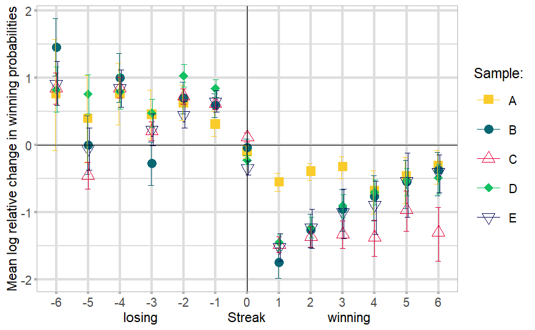

```r
pwin_change_relative <- pooled_table_unscaled %>%
  filter((streak < 7) & game_changed) %>%
  mutate(streak_signed = ifelse(status == "win",streak,-streak)) %>%
  group_by(streak_signed, label) %>%
  summarize(
    game_diff_mean = mean(game_diff_ratio+1),
    game_diff_logmean = mean(log(game_diff_ratio+1, base = 2)),
    game_diff_median = median(game_diff_ratio+1),
            .groups = "drop")

dset_change_relative <- pooled_table_unscaled %>%
  filter((streak < 7) & game_changed) %>%
  mutate(streak_signed = ifelse(status == "win",streak,-streak)) %>%
  mutate(game_diff_ratio_log = log(game_diff_ratio+1, base = 2)) %>%
  select(streak_signed, label, game_diff_ratio_log)

logmean <- function(data, i){
  mean(data[i])
}

p_level <- .01 #that is 1%

pwin_change_relative_boot <- dset_change_relative %>%
  group_by(streak_signed, label) %>%
  group_modify(
    function(.x,...){
    bootout <- boot::boot(.x$game_diff_ratio_log,
             logmean,
             R = 10000
    )
    return(
      tibble(
        logmean = mean(.x$game_diff_ratio_log),
        bottom = quantile(bootout$t, p_level/2),
        top = quantile(bootout$t, 1-p_level/2)
        )
      )
    }
  )

pwin_change_relative_boot %>%
  {ggplot(data = ., aes(x = factor(streak_signed), y = logmean, group = label)) +
  geom_point(aes(color = label, shape = label), size = 4)+
  geom_errorbar(aes(ymin = top, ymax = bottom, color = label), position = position_dodge(0.1)) +
  geom_hline(yintercept = 0) +
  geom_vline(xintercept = which(levels(factor(.$streak_signed)) %in% '0')) +
    theme_light() +
    theme(
      axis.title.x = element_text(colour="black", size = 13),
      axis.title.y = element_text(colour="black", size = 13),
      axis.text.y = element_text(size = 12),
      axis.text.x = element_text(size = 12),
      legend.position =  "right",
      legend.direction = "vertical",
      legend.text = element_text(colour="black", size = 12),
      legend.title = element_text(colour="black", size = 14),
      line = element_line(size = 2.5, lineend = "butt"),
      legend.key.size = grid::unit(2, "lines"),
      legend.key.width = unit(1,"cm")
    )  +
    scale_color_manual(values = c("#F9CC2C","#096773","#E7033C","#13C062","#111460")) +
    scale_shape_manual(values = c(15,16,24,18,25)) +
    #scale_y_continuous(labels = scales::trans_format(function(x)2^x, scales::math_format(.x))) +
    labs(
      x = "losing                   Streak                 winning",
      y = "Mean log relative change in winning probabilities",
      color = "Sample:",
      shape = "Sample:")}

setwd(WORKDIR)
ggsave("plots/figure_5_3.2.pdf", device = "pdf", width = 18.26,  height = 12.63,  units = "cm")
```

# Mean winning probability by longest winning or losing streak, using the player-level averaging approach in Xu and Harvey (2015) VS averaging over all bets placed by players with a given maximum streak length.

Here we have tried to replicate the analysis Xu and Harvey presented as a reaction to the critique of Demaree. They calculate average of user risk propensity, depending on the longest win/loss streaks reached by those users. They first create risk propensities for players, averaging the players’ chosen risk probabilites in their games and then averaging over the users, thus weighing the propensity of all users equally. We on the other hand only did the averaging over the games, after assigning them to the maximum streak lengths, thus weighing user propensities by the number of bets placed. The script produces figure 5.

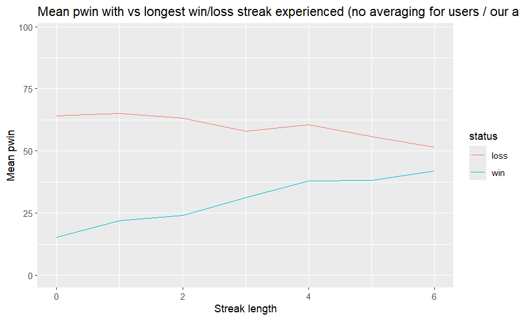

```r
#no averaging on user level before aggregation
#this represents the right thing to do
dset_xuanswer_longest_streak_length_signed_nonaggreg <- pooled_table_unscaled %>%
  select(userID, odds, pwin, streak, streak_total_length, status) %>%
  mutate(streak_total_length_signed = ifelse(status == "win", streak_total_length, -streak_total_length)) %>%
  group_by(userID) %>%
  mutate(streak_max_win = pmax(max(streak_total_length_signed),0),
         streak_max_loss = abs(pmin(min(streak_total_length_signed),0))) %>%
  ungroup() %>%
  {bind_rows(group_by(., streak_max_win) %>%
               summarise(mean_pwin = mean(pwin),
                         mean_multip = mean(odds),
                         n_of = n(),
                         .groups = "drop") %>%
               mutate(status = "win") %>%
               rename(streak_max = streak_max_win),
             group_by(.,streak_max_loss) %>%
               summarise(mean_pwin = mean(pwin),
                         mean_multip = mean(odds),
                         n_of = n(),
                         .groups = "drop") %>%
               mutate(status = "loss") %>%
               rename(streak_max = streak_max_loss))}
ggplot(dset_xuanswer_longest_streak_length_signed_nonaggreg, aes(x=streak_max, y=mean_pwin, group=status)) +
  geom_line(aes(color=status))+
  ggtitle("Mean pwin with vs longest win/loss streak experienced (no averaging for users / our approach)") +
  xlab("Streak length") +
  ylab("Mean pwin") +
  labs(group = "Win/loss streak") +
  xlim(0,6)
```

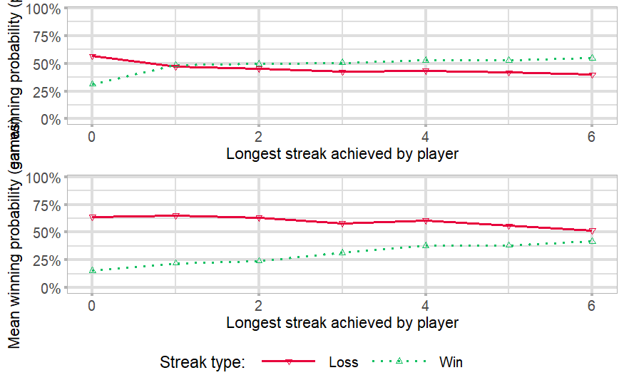

```r
#creating user averages before aggregation
#this represents the way Xu probably did it
dset_xuanswer_longest_streak_length_signed_useraggr <- pooled_table_unscaled %>%
  select(userID, odds, pwin, streak, streak_total_length, status) %>%
  mutate(streak_total_length_signed = ifelse(status == "win", streak_total_length, -streak_total_length)) %>%
  group_by(userID) %>%
  summarise(streak_max_win = pmax(max(streak_total_length_signed),0),
         streak_max_loss = abs(pmin(min(streak_total_length_signed),0)),
         user_mean_pwin = mean(pwin),
         user_mean_multip = mean(odds),
         n_games = n(),
         .groups = "drop") %>%
  {bind_rows(group_by(., streak_max_win) %>%
               summarise(mean_pwin = mean(user_mean_pwin),
                         mean_multip = mean(user_mean_multip),
                         n_of = n(),
                         .groups = "drop") %>%
               mutate(status = "win") %>%
               rename(streak_max = streak_max_win),
             group_by(.,streak_max_loss) %>%
               summarise(mean_pwin = mean(user_mean_pwin),
                         mean_multip = mean(user_mean_multip),
                         n_of = n(),
                         .groups = "drop") %>%
               mutate(status = "loss") %>%
               rename(streak_max = streak_max_loss))}
xuanswer_us <- ggplot(dset_xuanswer_longest_streak_length_signed_nonaggreg %>%
                      mutate(status = ifelse(status == "win","Win","Loss")),
                      aes(x=streak_max, y=mean_pwin/100, group=status)) +
  geom_line(aes(color = status, linetype = status), size = 1)+
  geom_point(aes(color = status, shape = status), size = 1.5) +
    theme_light() +
    theme(
      axis.title.x = element_text(colour="black", size = 13),
      axis.title.y = element_text(colour="black", size = 13),
      axis.text.y = element_text(size = 12),
      axis.text.x = element_text(size = 12),
      legend.position =  "bottom",
      legend.direction = "horizontal",
      legend.text = element_text(colour="black", size = 12),
      legend.title = element_text(colour="black", size = 14),
      line = element_line(size = 2.5, lineend = "butt"),
      legend.key.size = grid::unit(2, "lines"),
      legend.key.width = unit(2,"cm")
    )  +
    scale_color_manual(values = c("#E7033C","#13C062","#096773","#F9CC2C","#111460")) +
    scale_linetype_manual(values = c(1,3,2,4,5)) +
    scale_shape_manual(values=c(25, 24))+
    scale_y_continuous(labels=scales::percent_format()) +
    labs(
      x = "Longest streak achieved by player",
      y = "Mean winning probability (games)",
      color = "Streak type",
      linetype = "Streak type",
      shape = "Streak type") +
  xlim(0,6)
xuanswer_them <- ggplot(dset_xuanswer_longest_streak_length_signed_useraggr%>%
                      mutate(status = ifelse(status == "win","Win","Loss")),
                      aes(x=streak_max, y=mean_pwin/100, group=status)) +
  geom_line(aes(color = status, linetype = status), size = 1)+
  geom_point(aes(color = status, shape = status), size = 1.5) +
    theme_light() +
    theme(
      axis.title.x = element_text(colour="black", size = 13),
      axis.title.y = element_text(colour="black", size = 13),
      axis.text.y = element_text(size = 12),
      axis.text.x = element_text(size = 12),
      legend.position =  "bottom",
      legend.direction = "horizontal",
      legend.text = element_text(colour="black", size = 12),
      legend.title = element_text(colour="black", size = 14),
      line = element_line(size = 2.5, lineend = "butt"),
      legend.key.size = grid::unit(2, "lines"),
      legend.key.width = unit(2,"cm")
    )  +
    scale_color_manual(values = c("#E7033C","#13C062","#096773","#F9CC2C","#111460")) +
    scale_linetype_manual(values = c(1,3,2,4,5)) +
    scale_shape_manual(values=c(25, 24))+
    scale_y_continuous(labels=scales::percent_format()) +
    labs(
      x = "Longest streak achieved by player",
      y = "Mean winning probability (players)",
      color = "Streak type:",
      linetype = "Streak type:",
      shape = "Streak type:") +
  xlim(0,6)
ggpubr::ggarrange(xuanswer_them, xuanswer_us,
          ncol = 1, nrow = 2,  common.legend = TRUE, legend="bottom")

setwd(WORKDIR)
#ggsave("plots/figure_6_2.0.pdf", device = "pdf", width = 36.52,  height = 12.63,  units = "cm")
ggsave("plots/figure_6_2.1.pdf", device = "pdf", width = 20,  height = 28,  units = "cm")
```

# Fixed-effects regressions of within-person changes in chosen winning probabilities

We set up the indicator variables signaling the user experiencing long winning or losing streaks and game_diff_ratio_log is the same thing we used above at *Size of pwin change*. For the regression we will use feols from fixest to be able to controll over users.

```r
game_changer_set <- pooled_table_unscaled %>%
  select(userID, pwin, pwin_pred, game_diff_ratio, streak, status, label, game_streak) %>%
  mutate(win3 = ifelse((streak > 2)&(status == "win"), 1, 0)) %>%
  mutate(lose3 = ifelse((streak > 2)&(status == "loss"), 1, 0)) %>%
  mutate(win4 = ifelse((streak > 3)&(status == "win"), 1, 0)) %>%
  mutate(lose4 = ifelse((streak > 3)&(status == "loss"), 1, 0)) %>%
  mutate(win5 = ifelse((streak > 4)&(status == "win"), 1, 0)) %>%
  mutate(lose5 = ifelse((streak > 4)&(status == "loss"), 1, 0)) %>%
  mutate(win6 = ifelse((streak > 5)&(status == "win"), 1, 0)) %>%
  mutate(lose6 = ifelse((streak > 5)&(status == "loss"), 1, 0)) %>%
  mutate(win7 = ifelse((streak > 6)&(status == "win"), 1, 0)) %>%
  mutate(lose7 = ifelse((streak > 6)&(status == "loss"), 1, 0)) %>%
  mutate(game_diff_ratio_log = log(game_diff_ratio+1, base = 2))
```

Models over different cutoff lengths of “long streak”

```r
model_player_control_lag_only_changers_3 <- fixest::feols(
  game_diff_ratio_log ~ win3 + lose3 | userID,
  data = game_changer_set %>% filter(streak != game_streak),
  cluster = ~userID
)

summary(model_player_control_lag_only_changers_3)
```

```
OLS estimation, Dep. Var.: game_diff_ratio_log
Observations: 785,548
Fixed-effects: userID: 7,836
Standard-errors: Clustered (userID)
```

|  | Estimate | Std. Error | t value | Pr(>\|t\|) |  |
| --- | --- | --- | --- | --- | --- |
|  | -0.197655 | 0.028794 | -6.86454 | 7.1799e-12 | *** |
|  | 0.280920 | 0.029374 | 9.56341 | < 2.2e-16 | *** |

```
---
Signif. codes:  0 '***' 0.001 '**' 0.01 '*' 0.05 '.' 0.1 ' ' 1
RMSE: 2.01591     Adj. R2: 0.011383
                Within R2: 0.003048
```

```r
model_player_control_lag_only_changers_4 <- fixest::feols(
  game_diff_ratio_log ~ win4 + lose4 | userID,
  data = game_changer_set %>% filter(streak != game_streak),
  cluster = ~userID
)

summary(model_player_control_lag_only_changers_4)
```

```
OLS estimation, Dep. Var.: game_diff_ratio_log
Observations: 785,548
Fixed-effects: userID: 7,836
Standard-errors: Clustered (userID)
```

|  | Estimate | Std. Error | t value | Pr(>\|t\|) |  |
| --- | --- | --- | --- | --- | --- |
|  | -0.164710 | 0.028811 | -5.71697 | 1.1242e-08 | *** |
|  | 0.323866 | 0.031506 | 10.27942 | < 2.2e-16 | *** |

```
---
Signif. codes:  0 '***' 0.001 '**' 0.01 '*' 0.05 '.' 0.1 ' ' 1
RMSE: 2.01621     Adj. R2: 0.011088
                Within R2: 0.00275
```

The results below are the ones summarized in Table 3.

```r
model_player_control_lag_only_changers_5 <- fixest::feols(
  game_diff_ratio_log ~ win5 + lose5 | userID,
  data = game_changer_set %>% filter(streak != game_streak),
  cluster = ~userID
)

summary(model_player_control_lag_only_changers_5)
```

```
OLS estimation, Dep. Var.: game_diff_ratio_log
Observations: 785,548
Fixed-effects: userID: 7,836
Standard-errors: Clustered (userID)
```

|  | Estimate | Std. Error | t value | Pr(>\|t\|) |  |
| --- | --- | --- | --- | --- | --- |
|  | -0.131301 | 0.024763 | -5.30221 | 1.1753e-07 | *** |
|  | 0.262830 | 0.027522 | 9.54994 | < 2.2e-16 | *** |

```
---
Signif. codes:  0 '***' 0.001 '**' 0.01 '*' 0.05 '.' 0.1 ' ' 1
RMSE: 2.01748     Adj. R2: 0.009835
                Within R2: 0.001487
```

```r
model_player_control_lag_only_changers_6 <- fixest::feols(
  game_diff_ratio_log ~ win6 + lose6 | userID,
  data = game_changer_set %>% filter(streak != game_streak),
  cluster = ~userID
)

summary(model_player_control_lag_only_changers_6)
```

```
OLS estimation, Dep. Var.: game_diff_ratio_log
Observations: 785,548
Fixed-effects: userID: 7,836
Standard-errors: Clustered (userID)
```

|  | Estimate | Std. Error | t value | Pr(>\|t\|) |  |
| --- | --- | --- | --- | --- | --- |
|  | -0.114967 | 0.024789 | -4.63780 | 3.5785e-06 | *** |
|  | 0.308175 | 0.028082 | 10.97431 | < 2.2e-16 | *** |

```
---
Signif. codes:  0 '***' 0.001 '**' 0.01 '*' 0.05 '.' 0.1 ' ' 1
RMSE: 2.01729     Adj. R2: 0.010021
                Within R2: 0.001675
```

```r
model_player_control_lag_only_changers_7 <- fixest::feols(
  game_diff_ratio_log ~ win7 + lose7 | userID,
  data = game_changer_set %>% filter(streak != game_streak),
  cluster = ~userID
)

summary(model_player_control_lag_only_changers_7)
```

```
OLS estimation, Dep. Var.: game_diff_ratio_log
Observations: 785,548
Fixed-effects: userID: 7,836
Standard-errors: Clustered (userID)
```

|  | Estimate | Std. Error | t value | Pr(>\|t\|) |  |
| --- | --- | --- | --- | --- | --- |
|  | -0.092935 | 0.016262 | -5.71482 | 1.1384e-08 | *** |
|  | 0.241567 | 0.024170 | 9.99472 | < 2.2e-16 | *** |

```
---
Signif. codes:  0 '***' 0.001 '**' 0.01 '*' 0.05 '.' 0.1 ' ' 1
RMSE: 2.01806     Adj. R2: 0.009267
                Within R2: 9.139e-4
```

Summarizing coefficient values for different lenghts: Coefficient estimates in Table A1.

```r
c(model_player_control_lag_only_changers_3$coefficients,
  model_player_control_lag_only_changers_4$coefficients,
  model_player_control_lag_only_changers_5$coefficients,
  model_player_control_lag_only_changers_6$coefficients,
  model_player_control_lag_only_changers_7$coefficients) %>%
  matrix(nrow = 2, dimnames = list(c("win","loss"),c("3","4","5","6","7")))
```

```
              3          4          5          6           7
win  -0.1976546 -0.1647104 -0.1313010 -0.1149667 -0.09293531
loss  0.2809198  0.3238663  0.2628296  0.3081752  0.24156730
```

Summarizing coefficient standard errors for different lenghts: Coefficient estimate standard errors in Table A1.

```r
c(model_player_control_lag_only_changers_3$se,
  model_player_control_lag_only_changers_4$se,
  model_player_control_lag_only_changers_5$se,
  model_player_control_lag_only_changers_6$se,
  model_player_control_lag_only_changers_7$se) %>%
  matrix(nrow = 2, dimnames = list(c("win","loss"),c("3","4","5","6","7")))
```

```
              3          4          5          6          7
win  0.02879358 0.02881081 0.02476344 0.02478908 0.01626215
loss 0.02937444 0.03150628 0.02752159 0.02808150 0.02416950
```

# Empirical winning frequencies of players with and without streaks of different lengths

Here we are basically generating random sequences of outcomes for players who choose a random game from their initial set and stuck to it for n_games. Then we calculate the same observed winning probabilites Xu and Harwey worked with and plot it like we did for the data in the beginning. It produces figure A1.

```r
n_players <- 10000
n_games <- 100
#non-changing bots with uniform distribution of initial risk
sim_games_uniform <- lapply(runif(n_players), function(x)({
  rolls <- tibble(game = x, status = ifelse(runif(n_games) < x,"win","loss"), streak = 0)
  for(i in seq(1, n_games)){
    if(i == 1){
      rolls$streak = 0
    }else{
      #win streak
      if(rolls$status[i] == rolls$status[i-1]){
        rolls$streak[i] = rolls$streak[i-1]+1
      }else{
        rolls$streak[i] = 0
      }
    }
  }
  return(rolls)})) %>%
  bind_rows() %>%
  mutate(status_pred = lead(status, n = 1)) %>%
  drop_na()
winstreak_obs_winprob_uniform <- lapply(seq(1,10), function(i){
  sim_games_uniform %>%
  mutate(winstreak = ((status == "win")&(streak == i))) %>%
  group_by(winstreak) %>%
  summarize(n = n(), obs_pwin = sum(status_pred == "win")/n(), .groups = "drop") %>%
  mutate(streak = i)
}) %>%
  bind_rows() %>%
  mutate(winstreak = ifelse(winstreak, "In win streak", "Off win streak"))
losingstreak_obs_winprob_uniform <- lapply(seq(1,10), function(i){
  sim_games_uniform %>%
  mutate(lossstreak = ((status == "loss")&(streak == i))) %>%
  group_by(lossstreak) %>%
  summarize(n = n(), obs_pwin = sum(status_pred == "win")/n(), .groups = "drop") %>%
  mutate(streak = i)
}) %>%
  bind_rows() %>%
  mutate(lossstreak = ifelse(lossstreak, "In loss streak", "Off loss streak"))
#non-changing bots with initial risk distribution matching the distribution of the dataset
players_satoshi <- pooled_table_unscaled %>%
  pull(pwin) %>%
  table() %>%
  {setNames(as.vector(.)/sum(.)*n_players,names(.))}  %>%
  round() %>%
  {mapply(function(x, i) rep(i, x), ., names(.))} %>%
  unlist() %>%
  as.numeric()/100
sim_games_satoshi <- lapply(players_satoshi, function(x)({
  rolls <- tibble(game = x, status = ifelse(runif(n_games) < x,"win","loss"), streak = 0)
  for(i in seq(1, n_games)){
    if(i == 1){
      rolls$streak = 0
    }else{
      #win streak
      if(rolls$status[i] == rolls$status[i-1]){
        rolls$streak[i] = rolls$streak[i-1]+1
      }else{
        rolls$streak[i] = 0
      }
    }
  }
  return(rolls)})) %>%
  bind_rows() %>%
  mutate(status_pred = lead(status, n = 1)) %>%
  drop_na()
winstreak_obs_winprob_satoshi <- lapply(seq(1,10), function(i){
  sim_games_satoshi %>%
  mutate(winstreak = ((status == "win")&(streak == i))) %>%
  group_by(winstreak) %>%
  summarize(n = n(), obs_pwin = sum(status_pred == "win")/n(), .groups = "drop") %>%
  mutate(streak = i)
}) %>%
  bind_rows() %>%
  mutate(winstreak = ifelse(winstreak, "In win streak", "Off win streak"))
losingstreak_obs_winprob_satoshi <- lapply(seq(1,10), function(i){
  sim_games_satoshi %>%
  mutate(lossstreak = ((status == "loss")&(streak == i))) %>%
  group_by(lossstreak) %>%
  summarize(n = n(), obs_pwin = sum(status_pred == "win")/n(), .groups = "drop") %>%
  mutate(streak = i)
}) %>%
  bind_rows() %>%
  mutate(lossstreak = ifelse(lossstreak, "In loss streak", "Off loss streak"))
#non-changing bots with initial risk distribution consisting of two levels of 25% and 75%
players_twogames <- c(rep(.75,n_players/2), rep(.25,n_players/2))
sim_games_twogames <- lapply(players_twogames, function(x)({
  rolls <- tibble(game = x, status = ifelse(runif(n_games) < x,"win","loss"), streak = 0)
  for(i in seq(1, n_games)){
    if(i == 1){
      rolls$streak = 0
    }else{
      #win streak
      if(rolls$status[i] == rolls$status[i-1]){
        rolls$streak[i] = rolls$streak[i-1]+1
      }else{
        rolls$streak[i] = 0
      }
    }
  }
  return(rolls)})) %>%
  bind_rows() %>%
  mutate(status_pred = lead(status, n = 1)) %>%
  drop_na()
winstreak_obs_winprob_twogames <- lapply(seq(1,10), function(i){
  sim_games_twogames %>%
  mutate(winstreak = ((status == "win")&(streak == i))) %>%
  group_by(winstreak) %>%
  summarize(n = n(), obs_pwin = sum(status_pred == "win")/n(), .groups = "drop") %>%
  mutate(streak = i)
}) %>%
  bind_rows() %>%
  mutate(winstreak = ifelse(winstreak, "In win streak", "Off win streak"))
losingstreak_obs_winprob_twogames <- lapply(seq(1,10), function(i){
  sim_games_twogames %>%
  mutate(lossstreak = ((status == "loss")&(streak == i))) %>%
  group_by(lossstreak) %>%
  summarize(n = n(), obs_pwin = sum(status_pred == "win")/n(), .groups = "drop") %>%
  mutate(streak = i)
}) %>%
  bind_rows() %>%
  mutate(lossstreak = ifelse(lossstreak, "In loss streak", "Off loss streak"))
#Combining simulations
winstreak_obs_winprob_combined <- winstreak_obs_winprob_uniform %>% mutate(riskdist = "Uniform") %>%
  bind_rows(winstreak_obs_winprob_satoshi %>% mutate(riskdist = "Satoshi")) %>%
  bind_rows(winstreak_obs_winprob_twogames %>% mutate(riskdist = "Binary"))
losingstreak_obs_winprob_combined <- losingstreak_obs_winprob_uniform %>% mutate(riskdist = "Uniform") %>%
  bind_rows(losingstreak_obs_winprob_satoshi %>% mutate(riskdist = "Satoshi")) %>%
  bind_rows(losingstreak_obs_winprob_twogames %>% mutate(riskdist = "Binary"))
#Creating plot
simu_win <- ggplot(winstreak_obs_winprob_combined %>%
                     mutate(winstreak = ifelse(winstreak == "Off win streak","Off streak","On streak")),
                   aes(x=streak, y=obs_pwin, group=interaction(winstreak, riskdist))) +
  geom_line(aes(color = riskdist, linetype = riskdist), size = 1)+
  geom_point(aes(shape = winstreak), size = 1.5) +
    theme_light() +
    theme(
      axis.title.x = element_text(colour="black", size = 13),
      axis.title.y = element_text(colour="black", size = 13),
      axis.text.y = element_text(size = 12),
      axis.text.x = element_text(size = 12),
      legend.position =  "right",
      legend.direction = "vertical",
      legend.text = element_text(colour="black", size = 12),
      legend.title = element_text(colour="black", size = 14),
      line = element_line(size = 2.5, lineend = "butt"),
      legend.key.size = grid::unit(2, "lines"),
      legend.key.width = unit(2,"cm")
    )  +
    scale_color_manual(values = c("#F9CC2C","#E7033C","#096773","#13C062","#111460")) +
    scale_linetype_manual(values = c(1,3,2)) +
    scale_shape_manual(values=c(25, 24))+
    scale_y_continuous(labels=scales::percent_format(), limits = c(.15,.85)) +
    labs(
      x = "Winning streak length",
      y = "Measured mean winning probability",
      color = "Risk distribution:",
      linetype = "Risk distribution:",
      shape = "Streak type:") +
  guides(colour = guide_legend(order = 1),
          shape = guide_legend(order = 2),
          linetype = guide_legend(order = 1)) +
  xlim(c(0.9,6.1))
simu_loss <- ggplot(losingstreak_obs_winprob_combined %>%
                     mutate(lossstreak = ifelse(lossstreak == "Off loss streak","Off streak","On streak")),
                    aes(x=streak, y=obs_pwin, group=interaction(lossstreak, riskdist))) +
  geom_line(aes(color = riskdist, linetype = riskdist), size = 1)+
  geom_point(aes(shape = lossstreak), size = 2.2) +
    theme_light() +
    theme(
      axis.title.x = element_text(colour="black", size = 13),
      axis.title.y = element_text(colour="black", size = 13),
      axis.text.y = element_text(size = 12),
      axis.text.x = element_text(size = 12),
      legend.position =  "bottom",
      legend.direction = "horizontal",
      legend.text = element_text(colour="black", size = 12),
      legend.title = element_text(colour="black", size = 14),
      line = element_line(size = 2.5, lineend = "butt"),
      legend.key.size = grid::unit(2, "lines"),
      legend.key.width = unit(2,"cm")
    )  +
    scale_color_manual(values = c("#F9CC2C","#E7033C","#096773","#13C062","#111460")) +
    scale_linetype_manual(values = c(1,3,2)) +
    scale_shape_manual(values=c(25, 24))+
    scale_y_continuous(labels=scales::percent_format(), limits = c(.15,.85)) +
    labs(
      x = "Losing streak length",
      y = "Measured mean winning probability",
      color = "Risk distribution:",
      linetype = "Risk distribution:",
      shape = "Streak type:") +
  guides(colour = guide_legend(order = 1),
          shape = guide_legend(order = 2),
          linetype = guide_legend(order = 1)) +
  xlim(c(0.9,6.1))
ggpubr::ggarrange(simu_win, simu_loss,
          ncol = 2, nrow = 1,  common.legend = TRUE, legend="bottom")

setwd(WORKDIR)
ggsave("plots/figure_1_2.1.pdf", device = "pdf", width = 36.52,  height = 12.63,  units = "cm")
```

[output not shown]